# Lab 12 - Drzewa

Michał Ciach, Anna Macioszek

Na dzisiejszych laboratoriach poznamy nowe podejście do regresji i klasyfikacji, czyli metody drzewiaste takie jak drzewa regresji i klasyfikacji i lasy losowe.  
Będziemy korzystać z metod zaimplementowanych w pakietach `randomForest` i `rpart`.

### Drzewa CART

**Zadanie 1.** *Zadanie przykładowe.* Załaduj dane `biopsy` z pakietu `MASS`. Stwórz drzewo klasyfikacji które pomoże ocenić złośliwość nowotworu. Zbadaj błąd testowy za pomocą k-krotnej walidacji krzyżowej. Przytnij drzewo i sprawdź, czy poprawiło to klasyfikator. Wykorzystaj funkcje `rpart`, `plotcp` oraz `prune` z pakietu `rpart`.

**Rozwiązanie.** Dane `biopsy` oglądaliśmy już na laboratorium 10, więc odpuścimy sobie ten etap. Ładujemy pakiet `rpart` (oczywiście należy go wcześniej zainstalować) i budujemy drzewo. Oczywiście musimy w tym celu usunąć z modelu zmienną ID, ponieważ budowanie klasyfikatora wykorzystującego ID pacjenta nie ma żadnego sensu! Usuniemy również brakujące obserwacje (choć akurat drzewa decyzyjne dość dobrze sobie z nimi radzą, o czym można przeczytać m.in. w [manualu do pakietu rpart](https://cran.r-project.org/web/packages/rpart/vignettes/longintro.pdf)).  
Ponieważ kolumna `class` ma typ *factor*, to funkcja `rpart` domyśli się, że należy stworzyć drzewo klasyfikacji a nie regresji. Mimo to wyspecyfikujemy to za pomocą argumentu `method`. Domyślnie do stworzenia drzewa wykorzystany jest indeks Giniego. Liście drzewa są kolejno dzielone dopóki zapewnia to odpowiednio wysoką poprawę błędu klasyfikacji i dopóki liczba obserwacji odpowiadających liściowi nie spadnie poniżej określonego progu. Próg można zmodyfikować przekazując funkcji `rpart` odpowiednie argumenty w polu `control`, co opisuje dokładniej jej dokumentacja.

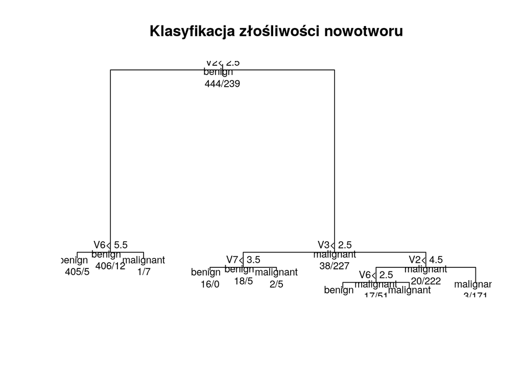

```r
library(MASS)
library(rpart)
biopsy$ID <- NULL
biopsy <- na.omit(biopsy)
drzewo <- rpart(class~., data=biopsy, method='class')
plot(drzewo, main="Klasyfikacja złośliwości nowotworu")
text(drzewo, use.n=TRUE, all=T, cex=.8)
```

Widzimy, że w pierwszym kroku nowotwory są rozdzielane za pomocą zmiennej V2, czyli jednorodności rozmiaru komórek, co jest zgodne z wiedzą dotyczącą histopatologii nowotworów. Próbki tkanki, dla których ta zmienna jest mniejsza niż 2.5 (a więc komórki mają stosunkowo jednorodne rozmiary), są następnie oceniane na podstawie zmiennej V6, czyli obecność w pewnym sensie nietypowych jąder komórkowych. Komórki dla których ta zmienna jest mniejsza niż 5.5 są oceniane jako nowotwór łagodny. W tym liściu mamy 405 obserwacji odpowiadających nowotworom łagodnym i 5 odpowiadających nowotworom złośliwym, a więc - gdyby drzewo było idealnie poprawne - skuteczność klasyfikacji w tym węźle wynosiłaby około 98.8%. Komórki, dla których zmienna V6 jest większa niż 5.5, oceniamy jako nowotwór złośliwy, ze skutecznością 7/(1+7) = 87.5%.

Przycięcie drzewa, czyli (w tym przypadku) złączenie niektórych liści, może poprawić błąd testowy, ponieważ zmniejsza wariancję predykcji - liście z większą liczbą obserwacji są mniej podatne na losowe błędy klasyfikacji. Funkcja `plotcp` umożliwia sprawdzenie błędu testowego w zależności od parametru złożoności drzewa (*cp*, ang. *complexity parameter*). Im mniejszy parametr cp, tym bardziej złożone drzewo - dla nieskończonej wartości otrzymujemy jedynie korzeń, czyli klasyfikator, który każdej obserwacji przypisuje klasę która najczęściej występuje w danych.

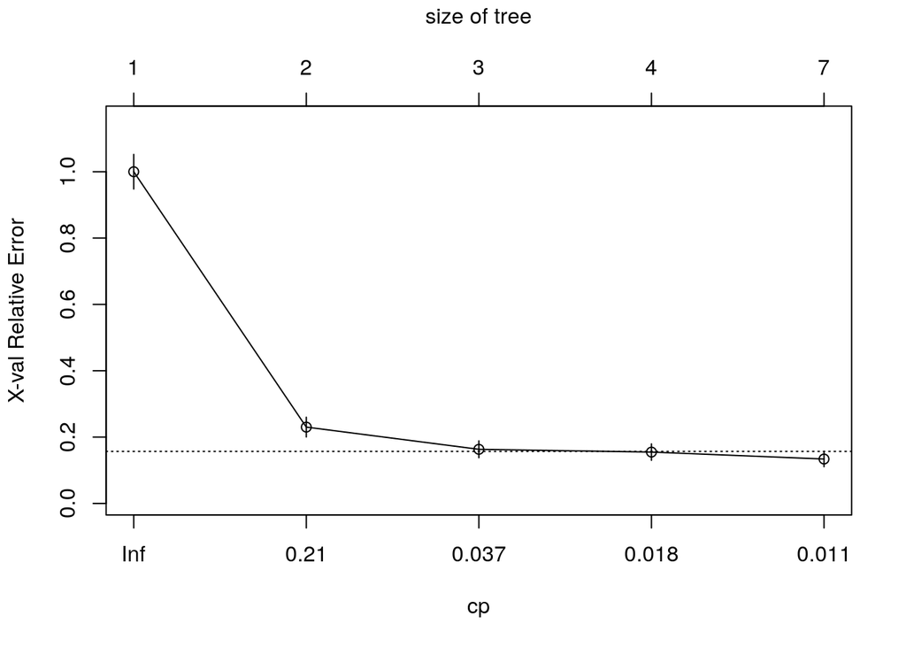

```r
plotcp(drzewo)
```

Wykres przedstawia błąd walidacji krzyżowej w odniesieniu do błędu drzewa z jednym liściem (dlatego wartości Inf odpowiada błąd równy 1 - jest to kwestia skalowania osi Y, a nie tego, że klasyfikator za każdym razem się myli). Dla parametru cp=0.011 otrzymujemy pełne drzewo. Przerywana linia pozioma reprezentuje błąd na pełnym drzewie plus jedno odchylenie standardowe tego błędu.  
Wybieramy karę cp=0.037, ponieważ zapewnia ona mały błąd przy jak najprostszym modelu. Wykorzystujemy tę karę aby przyciąć drzewo, które następnie wizualizuemy ponownie:

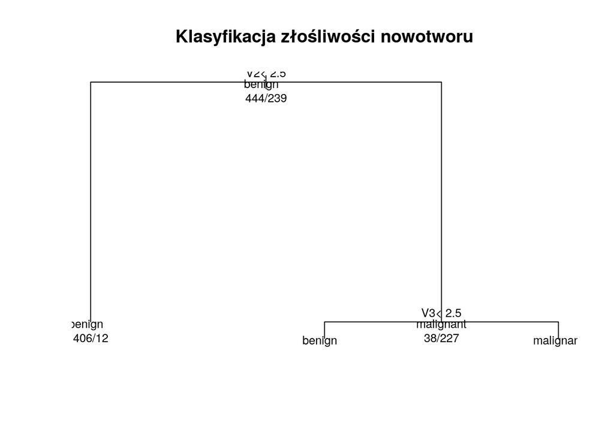

```r
przyciete_drzewo <- prune(drzewo, cp=0.037)
plot(przyciete_drzewo, main="Klasyfikacja złośliwości nowotworu")
text(przyciete_drzewo, use.n=TRUE, all=T, cex=.8)
```

Jak widać, otrzymane drzewo jest dużo prostsze. Między innymi omawiany wcześniej węzeł klasyfikujący nowotwory w zależności od zmiennej V6 został połączony w jeden liść, w którym dokładność klasyfikacji wynosi teraz 406/(406+12) = 97%.

Powyższą analizę można również przeprowadzić za pomocą pakietu `caret`. Dodatkowo pozwoli to na uzyskanie bezwzględnego błędu walidacji krzyżowej, zamiast błędu względem drzewa z jednym liściem. Taki błąd pozwoli nam porównać nasz model z modelem logistycznym, który badaliśmy na laboratorium 10.  
Aby otrzymać błąd bezwzględny możemy również przeprowadzić walidację krzyżową ręcznie, podobnie jak w laboratorium 10. Niestety nie udało mi się znaleźć funkcji która zrobiła by to za nas, czyli przeprowadziła walidację krzyżową na gotowym drzewie (pakiet `caret` liczy drzewo ponownie) - jeśli komuś uda się taką funkcję znaleźć, będę wdzięczny za informację.

```r
library(caret)
walidacja_caret <- train(class ~ .,
                          data=biopsy,
                          method="rpart",
                          trControl = trainControl(method = "cv", number=10),
                         tuneLength=10)  # ten parametr kontroluje liczbe wartosci parametru cp do przetestowania
walidacja_caret
```

```
## CART
##
## 683 samples
##   9 predictors
##   2 classes: 'benign', 'malignant'
##
## No pre-processing
## Resampling: Cross-Validated (10 fold)
## Summary of sample sizes: 615, 614, 615, 615, 615, 615, ...
## Resampling results across tuning parameters:
##
##   cp          Accuracy   Kappa
##   0.00000000  0.9501705  0.8911613
##   0.08786611  0.9194160  0.8241398
##   0.17573222  0.9194160  0.8241398
##   0.26359833  0.9194160  0.8241398
##   0.35146444  0.9194160  0.8241398
##   0.43933054  0.9194160  0.8241398
##   0.52719665  0.9194160  0.8241398
##   0.61506276  0.9194160  0.8241398
##   0.70292887  0.9194160  0.8241398
##   0.79079498  0.7482097  0.3090500
##
## Accuracy was used to select the optimal model using the largest value.
## The final value used for the model was cp = 0.
```

Najwyższa dokładność, odpowiadająca parametrowi cp = 0 (czyli pełnemu drzewu), wyniosła ~95%. Jest zatem nieco niższa niż w przypadku modelu logistycznego, dla którego wniosła 96.6%. Na podstawie wyników możemy również oszacować, że dla przyjętej wcześniej wartości cp=0.037 dokładność wynosi około 92%. Zauważmy, że kosztem nieco niższej dokładności otrzymujemy zdecydowanie prostszy model.

**Zadanie 2.** Drzewo klasyfikacyjnie domyślnie przypisuje nowej obserwacji tę klasę, która występuje najczęściej w odpowiednim liściu. Jakkolwiek rozwiązanie to jest bardzo intuicyjne, wiąże się z nim pewien problem. Jeśli test diagnostyczny mówi, że pacjent na 51% jest zdrowy, a na 49% ma złośliwy nowotwór, to niekoniecznie chcemy uznać że jest fajnie i odesłać go do domu.  
Żeby uzyskać trochę bezpieczniejszą klasyfikację wykorzystujemy ważenie danych. Klasie $k$ przypisujemy wagę $w_k$, a nową obserwację przypisujemy do “cięższej” klasy. Na przykład, w liściu w którym mamy 1 nowotwór złośliwy i 5 łagodnych, nowej obserwacji przypiszemy klasę ‘złośliwy’ jeśli waga tej klasy będzie co najmniej 5 razy wyższa niż waga klasy ‘łagodny’. Jest to analogiczne podejście do progu prawdopodobieństwa, którego używaliśmy w regresji logistycznej. Jeśli wagi sumują się do 1, mówimy o prawdopodobieństwach klas *a priori* - interpretujemy je jako ogólne prawdopodobieństwo, że jakaś obserwacja należy do danej klasy (gdy nie znamy odpowiadających jej wartości predyktorów).  
Aby przypisać nową obserwację do konkretnej klasy, mnożymy prawdopodobieństwa *a priori* przez prawdopodobieństwa empiryczne, czyli te, które otrzymujemy obliczając proporcje klas w danym liściu - jest to to samo, co unormowana “waga” danej klasy. Obserwacji przypisujemy tę klasę, dla której otrzymujemy najwyższą wartość takiego iloczynu.  
W przypadku dwóch klas jest to równoznaczne z ustaleniem progu prawdopodobieństwa, tak samo jak w przypadku regresji logistycznej. Warto jednak wiedzieć, że drzewa decyzyjne pozwalają łatwo uogólnić tę procedurę na większą liczbę klas.

Podziel dane `biopsy` na zbiór testowy i treningowy. Zbuduj drzewo decyzyjne na zbiorze treningowym i przeprowadź predykcję na zbiorze testowym za pomocą funkcji `predict`. Funkcja ta zwróci prawdopodobieństwa empiryczne poszczególnych klas.  
Utwórz wektor progów od 0 do 1. Dla każdego progu zaklasyfikuj obserwacje, przypisując klasę ‘malignant’ jeśli jej prawdopodobieństwo przekroczy próg, i oblicz True Positive Rate (procent nowotworów złośliwych zaklasyfikowanych jako łagodne) oraz False Positive Rate (procent nowotworów łagodnych zaklasyfikowanych jako złośliwe). W tym celu przyda się pętla `for`. W celu obliczenia TPR i FPR można stworzyć macierz błędu korzystając z funkcji `table`.  
Utwórz krzywą ROC. Sprawdź, jaki procent nowotworów złośliwych zaklasyfikujemy jako łagodne w sytuacji, gdy (na przykład ze względów na koszty związane z dalszą terapią) możemy pozwolić sobie na zaklasyfikowanie jedynie 10% nowotworów łagodnych jako złośliwe.

*Opcja dla ambitnych:* Wykorzystując $k$-krotną walidację krzyżową utwórz $k$ krzywych ROC i przedstaw je na jednym wykresie. W tym przypadku trzeba przeprowadzić walidację krzyżową ręcznie, na przykład korzystając z funkcji `cut` oraz `which`.

*Uwaga.* W odróżnieniu od regresji logistycznej pakiet `rpart` może wykorzystać wagi i macierz kosztu nie tylko podczas klasyfikowania nowej obserwacji, ale również podczas budowania drzewa, tak aby zoptymalizować pod tym kątem predykcję. Można to zrealizować komendą `rpart(class~., data=biopsy, method='class', parms=list('prior'=wektor_unormowanych_wag))`.  
Prowadzi to jednak do sytuacji, w której dla każdego zestawu prawdopodobieństw otrzymujemy inny klasyfikator. Jedną z konsekwencji tego faktu jest to, że nie możemy zbudować sensownej krzywej ROC.  
Bardziej ogólnym sposobem ważenia danych jest podanie *macierzy kosztu* $L$, w której wyraz $L_{ij}$ oznacza koszt predykcji klasy $j$, gdy prawdziwą klasą jest $i$. W typowych zastosowaniach $L_{kk} = 0$, a wszystkie pozostałe wyrazy są dodatnie. Funkcja `rpart` umożliwia również korzystanie z macierzy kosztu podczas budowania drzewa.

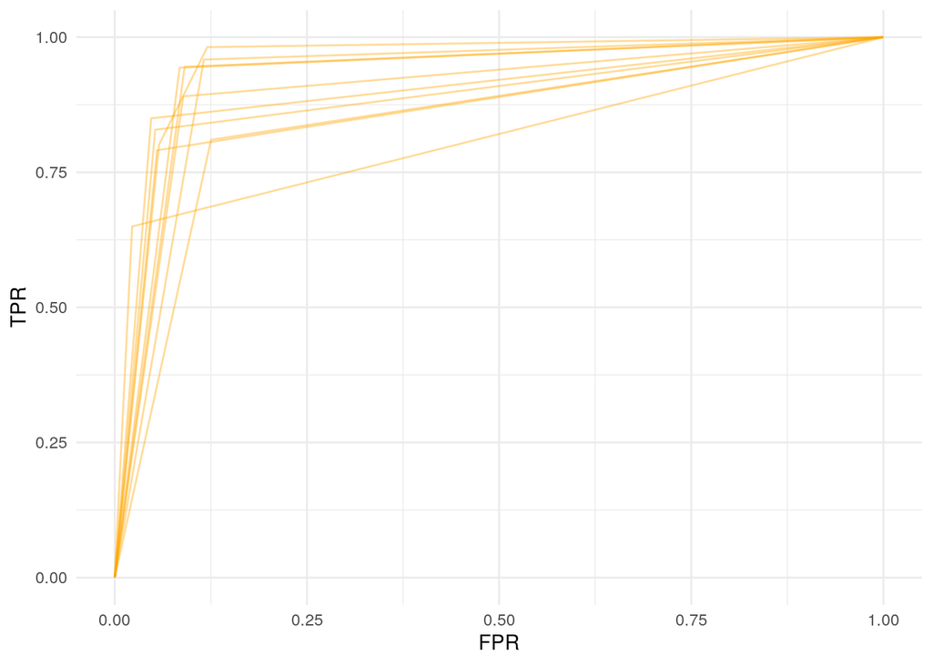

```r
library(ggplot2)
ggplot(roc_data, aes(x=FPR, y=TPR, group=CV)) + geom_line(alpha=0.4, color='orange') + theme_minimal()
```

### Lasy losowe

Znajomy chemik kwantowy, gdy pierwszy raz zobaczył wzór na regresję LASSO, skonstatował: “Aha. Czyli chodzi o to, żeby dopasować prostą do punktów, tylko tak niezbyt dobrze. Wy naprawdę nie macie nic lepszego do roboty na tej statystyce?”.

Lasy losowe to kolejna metoda w której poprawiamy poprzez psucie. W pierwszym kroku na podstawie naszych danych losujemy pewną liczbę $B$ prób bootstrapowych (czyli $B$-krotnie losujemy z naszych danych $n$ obserwacji ze zwracaniem, gdzie $n$ zawsze jest równe wyściowej liczbie obserwacji). W następnym kroku na każdej próbie bootstrapowej budujemy drzewo losowe, ale żeby przypadkiem nie zbudować go zbyt dobrze, za każdym razem dzieląc węzeł losujemy $m$ predyktorów, i dzielimy węzeł korzystając jedynie z nich. Okazuje się, że to poprawia błąd testowy. Formalny dowód tego faktu można znaleźć m.in. w [oryginalnej pracy](https://link.springer.com/content/pdf/10.1023/A:1010933404324.pdf) Leo Breimana z 2001 r. Z kolei proste wprowadzenie do tematyki lasów losowych można obejrzeć [tutaj](https://www.youtube.com/watch?v=D_2LkhMJcfY).

Do budowania lasów losowych w R służy funkcja `randomForest` z biblioteki o tej samej nazwie.  
Cała procedura wygląda tak samo jak w przypadku pozostałych metod - wpisanie w konsolę nazwy utworzonego modelu wyświetli podstawowe informacje, działają również funkcje `summary`, `plot`, `predict` itd.

Walidację krzyżową lasu losowego można przeprowadzić ręcznie (patrz Lab10) lub korzystając z pakietu `caret`. Sposób jego użycia jest praktycznie taki sam jak w przypadku pozostałych modeli - szczegóły można znaleźć wpisując w Google “random forests in caret”.  
Korzystając z funkcji `randomForest` warto przekazać argument `importance = TRUE`, aby funkcja oceniła istotność zmiennych - czyli intuicyjnie mówiąc to, jak duży wpływ ma każda z nich na predykcję, lub jak mocno zmieniła by się predykcja gdyby tę zmienną usunąć z danych. Jest to co innego niż istotność statystyczna - zbieżność nazw w języku polskim jest przypadkowa. Dokładniejsze wyjaśnienie istotności cech w lasach losowych można znaleźć m.in. [tutaj](https://www.displayr.com/how-is-variable-importance-calculated-for-a-random-forest/) lub w książce [The Elements of Statistical Learning](https://link.springer.com/book/10.1007/978-0-387-84858-7).

**Zadanie 3.** Zbuduj las losowy przewidujący złośliwość nowotworu na danych `biopsy`. Sprawdź, czy jego dokładność w walidacji krzyżowej przebije 96%, czyli tę którą osiągnęliśmy korzystając z modelu logistycznego. Estymowany błąd testowy znajdziesz w podstawowych informacjach dotyczących utworzonego modelu, które uzyskasz wpisując jego nazwę w konsolę. Jest on opisany jako ‘OOB estimate of error rate’ - jest to tak zwany błąd *out-of-bag*, który przybliża błąd walidacji krzyżowej. Przedstaw istotność zmiennych na wykresie, wykorzystując funkcję `varImpPlot` lub bibliotekę `ggplot2`. Możesz również przetestować różne liczby zmiennych losowanych przy podziale węzłów modyfikując atrybut `mtry`. Możesz też zmienić liczbę drzew za pomocą argumentu `ntrees`. Może być tu pomocna funkcja `plot`, która wywołana na utworzonym modelu przedstawi zależność błędu testowego od liczby użytych drzew. W praktyce bierze się po prostu “dostatecznie dużo” drzew (na przykład 500) i nie przeprowadza dodatkowych analiz dotyczących ich optymalnej liczby, ponieważ ma to bardzo nieznaczny wpływ na błąd. Więcej informacji na ten temat można przeczytać [tutaj](https://stats.stackexchange.com/questions/348245/do-we-have-to-tune-the-number-of-trees-in-a-random-forest).

*Dla chętnych:* Przeprowadź ręcznie walidację krzyżową i porównaj z estymatorem OOB.

Dla ułatwienia, stworzony model powinien wyglądać następująco:

```r
las
```

```
##
## Call:
##  randomForest(formula = class ~ ., data = biopsy, importance = TRUE,      mtry = 4, ntree = 400)
##                Type of random forest: classification
##                      Number of trees: 400
## No. of variables tried at each split: 4
##
##         OOB estimate of  error rate: 2.93%
## Confusion matrix:
##           benign malignant class.error
## benign       432        12  0.02702703
## malignant      8       231  0.03347280
```

Poniżej zamieszczam również wartość średnią oraz wykres pudełkowy błędu testowego obliczonego na podstawie ręcznie przeprowadzonej 10-krotnej walidacji krzyżowej:

```r
mean(bledy_walidacji)
```

```
## [1] 0.0445735
```

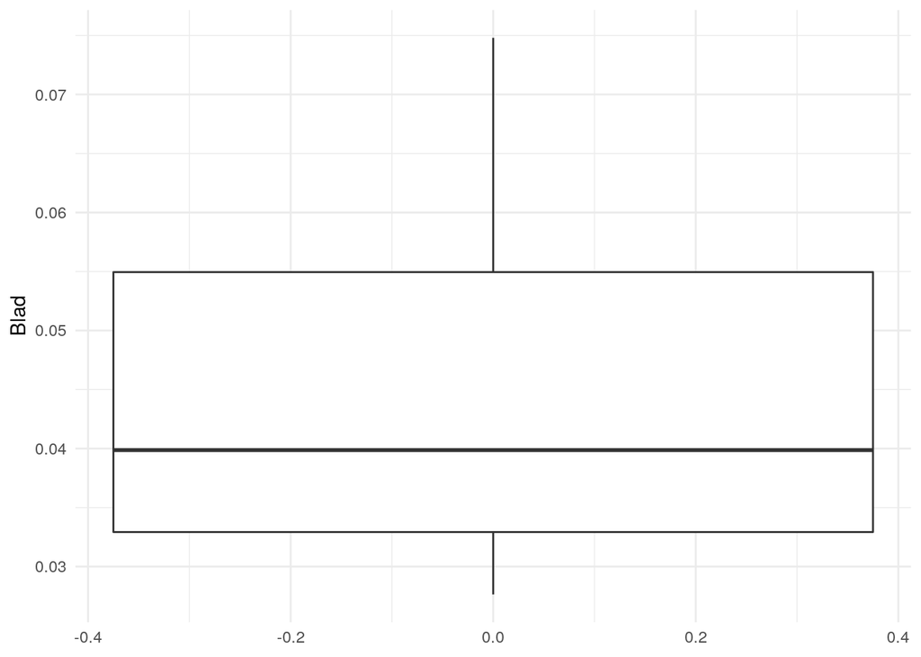

```r
ggplot(data.frame('Blad'=bledy_walidacji)) + geom_boxplot(aes(y=Blad)) + theme_minimal()
```

Tutaj natomiast mamy ręcznie utworzony wykres słupkowy przedstawiający istotność zmiennych (atrybut `importance` utworzonego modelu, zapisanego w zmiennej `las`, jest nieco nietypową zmienną, dlatego trzeba się trochę nakombinować żeby przekształcić go do ramki danych):

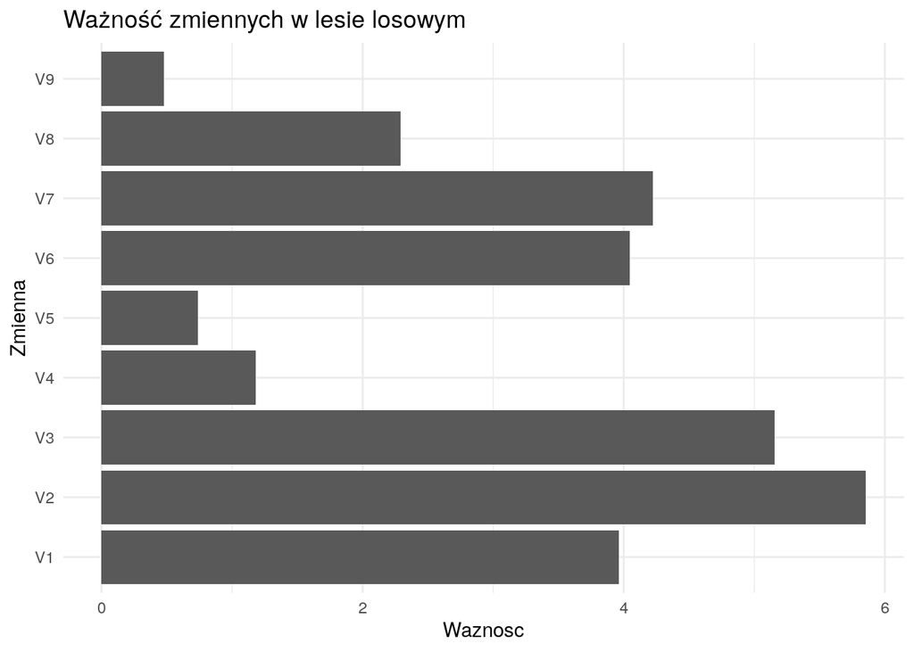

```r
waznosc <- las$importance
ggplot(data.frame('Zmienna' = rownames(waznosc), 'Waznosc' = as.numeric(waznosc))) + geom_col(aes(x=Zmienna, y=Waznosc)) + coord_flip() + theme_minimal() + ggtitle('Ważność zmiennych w lesie losowym')
```

## Zadania dodatkowe.

**Zadanie 4.** *Indeks Giniego.* Załóżmy, że mamy 20 obserwacji - 10 zielonych, 10 fioletowych. Rozpatrzmy drzewo klasyfikacyjne, które ma dwa liście.

1. Załóżmy, że do każdego liścia przypisujemy 10 obserwacji. Stwórz wykres przedstawiający indeks Giniego dla pierwszego liścia w zależności od liczby przypisanych mu fioletowych obserwacji.
2. Przedstaw zależność indeksu Giniego od liczby obserwacji fioletowych przypisanych do pierwszego liścia w sytuacji, gdy do liscia przypisujemy dowolną liczbę obserwacji (od 1 do 19). Możesz zrobić to na dwa sposoby:
- Wykres trójwymiarowy - na dwóch osiach poziomych liczby obserwacji zielonych i fioletowych przypisanych do wybranego liścia, na pionowej indeks Giniego. Można taki wykres zrobić za pomocą funkcji `persp`. Dla czytelności polecam pokolorować wykres. Warto też go poobracać, manipulując argumentami `phi` i `theta`.
- Wykres dwuwymiarowy - na osiach liczby obserwacji fioletowych i zielonych przypisanych do pierwszego liścia, indeks Giniego przedstawiony za pomocą koloru lub wielkości punktu.

**Zadanie 5.** *Boosting.* Obejrzyj dane `Khan` z pakietu `ISLR`. Będziemy zajmować się przewidywaniem typu nowotworu na podstawie ekspresji genów. Zauważ, że dane są listą podzieloną już na zbiór treningowy i testowy.

Wykonaj procedurę boosting do predykowania typu nowotworu (zmienna `y`), korzystając z funkcji `gbm` z biblioteki o tej samej nazwie. Użyj zbioru `train` do trenowania, a `test` do testowania. Wygeneruj 500 drzew (domyślna wartość 100 jest trochę mała). Przetestuj różne wartości parametru `shrinkage`, najlepiej wykorzystując siatkę parametrów. Przykładową siatkę parametrów długości `n` możesz stworzyć komendą `seq(0.001, 0.9, length.out = n)`. Narysuj wykres zależności błędu testowego w zależności od parametru `shrinkage`.

Dla chętnych: za pomocą walidacji krzyżowej oszacuj, najlepszą wartość parametru `shrinkage` oraz liczby generowanych drzew.

*Uwaga*: w przypadku lasów losowych i baggingu nie da się przetrenować modelu zwiększając liczbę drzew; w przypadku boostingu owszem. Liczba drzew zatem również powinna zostać ostrożnie dobrana, np. za pomocą walidacji krzyżowej.

**Zadanie 6.** Porównaj drzewa klasyfikacji i lasy losowe na danych `Khan` z pakietu `ISLR`:

1. Wykonaj klasyfikację za pomocą drzewa klasyfikującego korzystając z funkcji `rpart` z pakietu o tej samej nazwie. Zwizualizuj drzewo za pomocą funkcji `plot`. Które predyktory zostały wykorzystane? Porównaj ich średnie i wariancje między klasami.
2. Przytnij uzyskane drzewo tak, żeby miało trzy liście. Wykorzystaj funkcję `prune`.
3. Zbuduj las losowy, wykorzystując w każdej iteracji maksymalnie 20 predyktorów. Policz średni błąd testowy. Wykorzystaj funkcję `randomForest` z biblioteki o tej samej nazwie; najlepiej uruchomić z argumentem `importance = TRUE`.
4. Powtórz punkt 3 od kilku do kilkunastu razy dla różnej liczby rozważanych predyktorów. Narysuj wykres zależności błędu testowego od liczby predyktorów. Czy podobne predyktory zostały uznane za najistotniejsze przez las losowy i zwykłe pojedyncze drzewo? Czy różna liczba uwzględnianych predyktorów przy budowaniu lasu wpłynęła na wybór najistotniejszych predyktorów?
5. Narysuj wykres istotności predyktorów za pomocą funkcji `varImpPlot`, najlepiej dla kilku różnych lasów losowych.

Po wykonaniu tego zadania zastanów się, jak przy użyciu funkcji `randomForest` wykonać procedurę bagging.